# Normal Distribution

## The Normal Distribution

The normal (also known as ‘Gaussian’) is $X\sim N(\mu,\sigma^2)$:

- $\mu$ is the expected value ($E[X]$)
- $\sigma^2$ is the variance of (Var$[X]$)

Its pdf:
$$f(x)=\frac1{(2\pi\sigma^2)^{1/2}}e^{-\frac{(x-\mu)^2}{2\sigma^2}}$$
Just like the binomial, you don’t need to know this formula for this class..

## The Normal Distribution

Computing probabilities with the normal **requires** computers

Luckily, we already know the general idea…

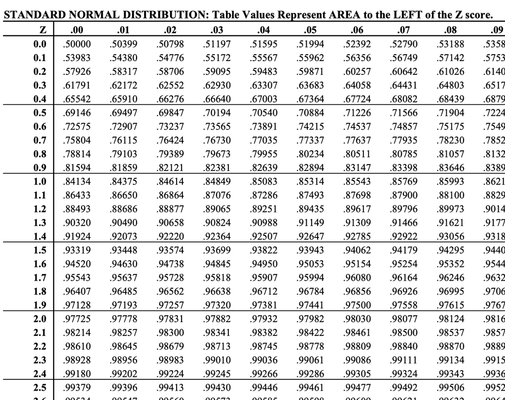

```r
pnorm(1.8,0,1)
```

```
[1] 0.9640697
```

```r
pnorm(1.89,0,1)
```

```
[1] 0.970621
```

## Computing probabilities

We will always write $X\sim N(\mu,\sigma^2)$ for the normal distribution

R syntax will be specified with the mean and standard deviation

#### Example

If $X \sim N(5,9)$, then the probability $X$ is less than 4 is:

```r
x       = 4
mu      = 5
sigmaSq = 9
pnorm(x, mu, sqrt(sigmaSq))
```

```
[1] 0.3694413
```

## Computing probabilities

#### Example

Suppose that the scores on the SAT math section are normally distributed with an expected value of 520 and a variance of 3600.

We can write this succinctly as

$$X \sim N(520, 3600)$$

What is the probability someone scores less than 600?

[figure not shown]

. . .

```r
x       = 600
mu      = 520
sigmaSq = 3600
pnorm(x, mu, sqrt(sigmaSq))
```

```
[1] 0.9087888
```

## Computing values

Writing $X\sim N(\mu,\sigma^2)$ for the normal distribution, if $X \sim N(5,9)$:

### Probability

Probability: then the probability $X$ is less than 4 ($P(X < 4)$) is:

```r
pnorm(4,5,3)
```

```
[1] 0.3694413
```

. . .

### Values

Values: at what value $x$ does $P(X\leq x) = .7$? . . .

```r
qnorm(.7,5,3)
```

```
[1] 6.573202
```